# CSE204 - Introduction to Machine Learning - Lab Session 2: parametric models

#### Question 4

Restart the optimization using a different *learning rate* $\eta$. What do you observe?

If $\eta$ is too small, it converges very slowly toward the optimum.

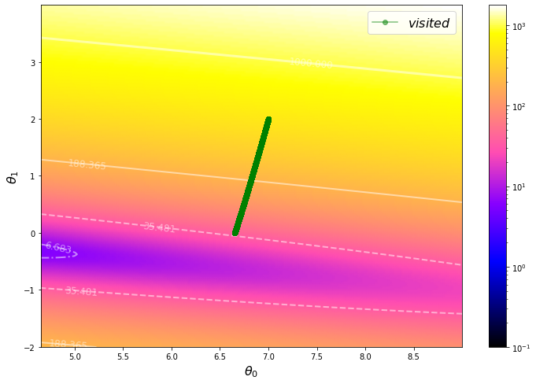

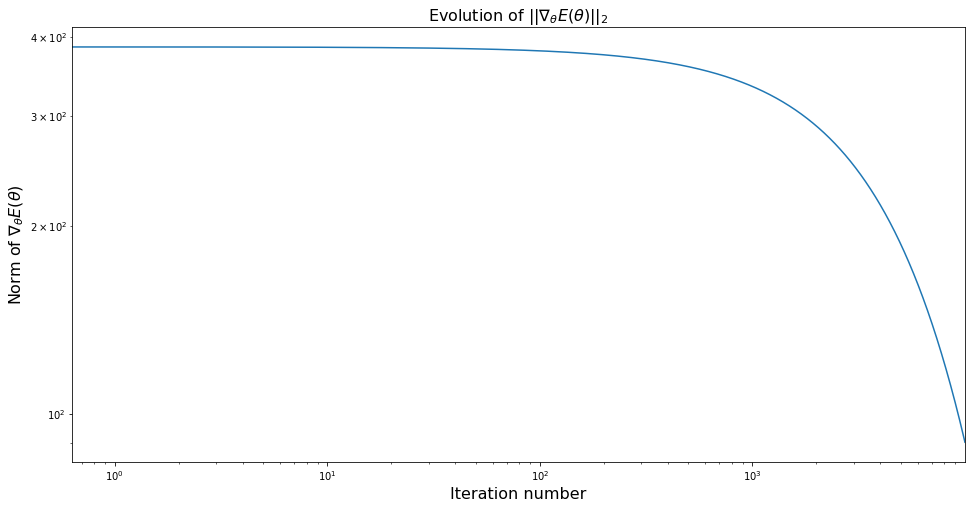

```python
### BEGIN SOLUTION
grad_list, theta_list = gradient_descent(X, y, eta=0.000001, initial_theta=np.array([[7],[2]]))

df_grad = pd.DataFrame(grad_list, columns=["grad1", "grad2"])
df_theta = pd.DataFrame(theta_list, columns=["theta1", "theta2"])

theta_min = df_theta.min().values
theta_max = df_theta.max().values

plot_contour_2d_solution_space(mse,
                               theta_min=theta_min - 2.,
                               theta_max=theta_max + 2.,
                               theta_visited=df_theta.values.T);
df_grad['norm'] = np.sqrt(df_grad['grad1']**2 + df_grad['grad2']**2)
ax = df_grad.norm.plot(loglog=True, figsize=(16, 8))

ax.set_title(r"Evolution of $||\nabla_{\theta} E(\theta)||_2$", fontsize=16)
ax.set_xlabel("Iteration number", fontsize=16)
ax.set_ylabel(r"Norm of $\nabla_{\theta} E(\theta)$", fontsize=16);
### END SOLUTION
```

With a larger value, the algorithm oscillates but eventually converges.

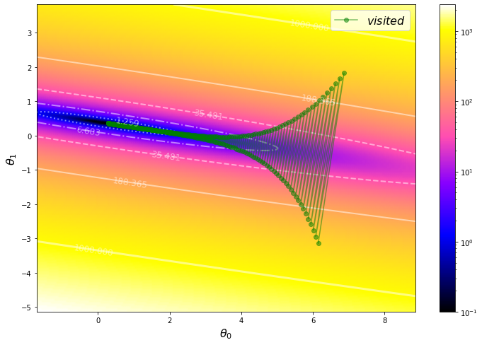

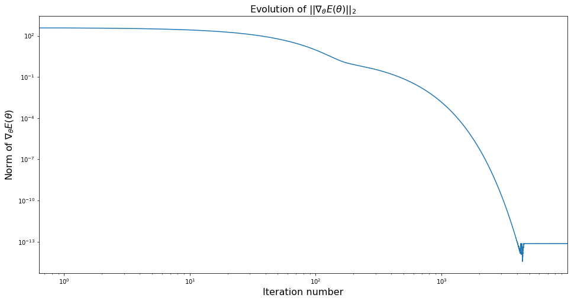

```python
### BEGIN SOLUTION
grad_list, theta_list = gradient_descent(X, y, eta=0.0135, initial_theta=np.array([[7],[2]]))

df_grad = pd.DataFrame(grad_list, columns=["grad1", "grad2"])
df_theta = pd.DataFrame(theta_list, columns=["theta1", "theta2"])

theta_min = df_theta.min().values
theta_max = df_theta.max().values

plot_contour_2d_solution_space(mse,
                               theta_min=theta_min - 2.,
                               theta_max=theta_max + 2.,
                               theta_visited=df_theta.values.T);
df_grad['norm'] = np.sqrt(df_grad['grad1']**2 + df_grad['grad2']**2)
ax = df_grad.norm.plot(loglog=True, figsize=(16, 8))

ax.set_title(r"Evolution of $||\nabla_{\theta} E(\theta)||_2$", fontsize=16)
ax.set_xlabel("Iteration number", fontsize=16)
ax.set_ylabel(r"Norm of $\nabla_{\theta} E(\theta)$", fontsize=16);
### END SOLUTION
```

If $\eta$ is too large, the algorithm diverges and makes an overflow error (i.e. solutions value become too large to be contained in a float variable).

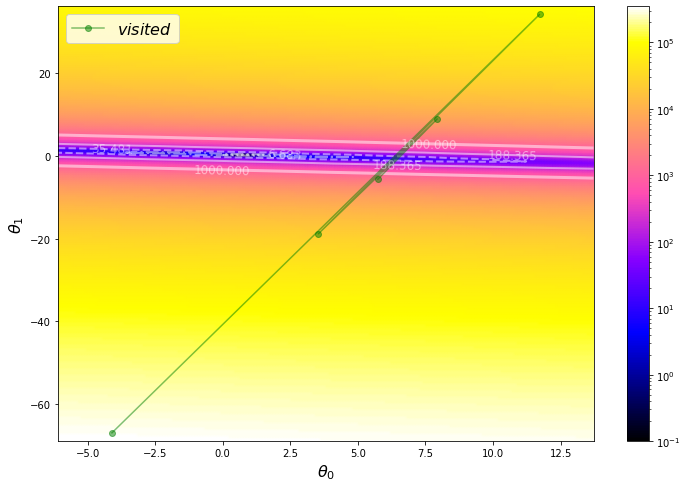

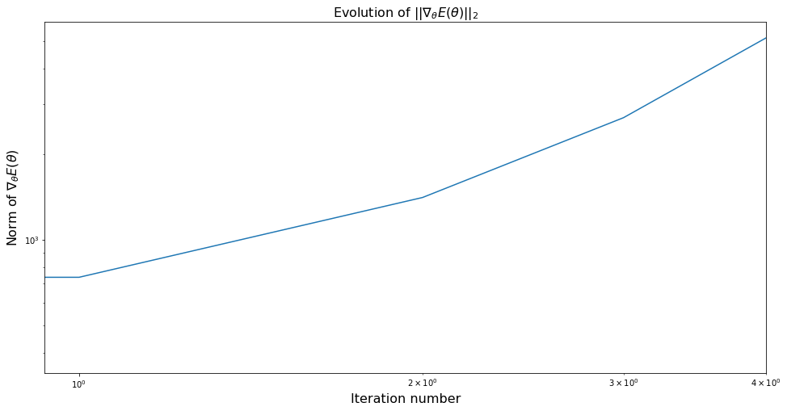

```python
### BEGIN SOLUTION
grad_list, theta_list = gradient_descent(X, y, eta=0.02, max_iteration=5, initial_theta=np.array([[7],[2]]))

df_grad = pd.DataFrame(grad_list, columns=["grad1", "grad2"])
df_theta = pd.DataFrame(theta_list, columns=["theta1", "theta2"])

theta_min = df_theta.min().values
theta_max = df_theta.max().values

plot_contour_2d_solution_space(mse,
                               theta_min=theta_min - 2.,
                               theta_max=theta_max + 2.,
                               theta_visited=df_theta.values.T);
df_grad['norm'] = np.sqrt(df_grad['grad1']**2 + df_grad['grad2']**2)
ax = df_grad.norm.plot(loglog=True, figsize=(16, 8))

ax.set_title(r"Evolution of $||\nabla_{\theta} E(\theta)||_2$", fontsize=16)
ax.set_xlabel("Iteration number", fontsize=16)
ax.set_ylabel(r"Norm of $\nabla_{\theta} E(\theta)$", fontsize=16);
### END SOLUTION
```

## Linear regression with Scikit Learn

Let's play with the Scikit Learn implementation of linear regression. The official documentation is there: https://scikit-learn.org/stable/modules/linear_model.html

Use the `gen_1d_linear_regression_samples()` function (defined above) to generate a dataset and `plot_1d_regression_samples()` to plot it.

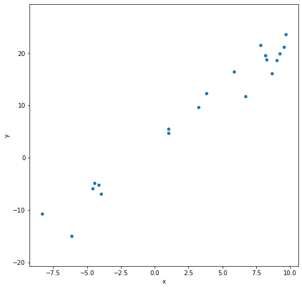

```python
df = gen_1d_linear_regression_samples()

plot_1d_regression_samples(df)
```

Once the dataset is ready, let's make the regressor and train it with the following code:

```python
model = sklearn.linear_model.LinearRegression()

model.fit(df[['x']], df[['y']])
```

```
LinearRegression(copy_X=True, fit_intercept=True, n_jobs=None, normalize=False)
```

The following cell plots the learned model (the red dashed line) and the dataset $\mathcal{D}$ (blue points).

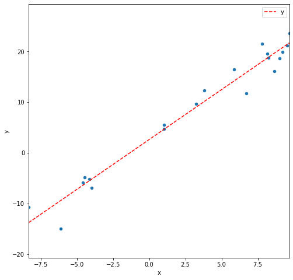

```python
plot_1d_regression_samples(df, model=model)
```

### Exercise 4

#### Question 1

What are the optimal parameters $\theta_1$ (intercept) and $\theta_2$ obtained? (use `model.coef_` and `model.intercept_` attributes)

```python
### BEGIN SOLUTION
print("Model slope:    ", model.coef_[0])
print("Model intercept:", model.intercept_)
### END SOLUTION
```

```
Model slope:     [1.968802]
Model intercept: [2.6296381]
```

#### Question 2

Write the mathematical definition of your model.

The `gen_1d_linear_regression_samples()` returns randomly noised data, thus form one call to another the dataset $\mathcal{D}$ changes. The slope and intercept of your model slightly changes too but it should be close to this:

$y \approx 2 x + 3$

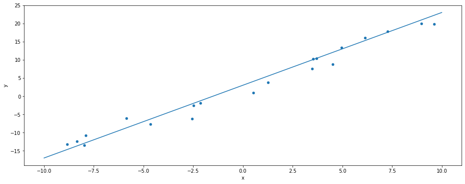

```python
### BEGIN SOLUTION
df = gen_1d_linear_regression_samples()

def f(X):
    return 2 * X + 3

ax = df.plot.scatter(x='x', y='y', figsize=(16, 6))

X = np.array([-10, 10])
ax.plot(X, f(X));
### END SOLUTION
```

#### Question 3

Use the `model.predict()` function to guess the class of the following points:

$$x_{p1} = -2, \quad x_{p2} = 2, \quad x_{p3} = 6$$

```python
### BEGIN SOLUTION
model.predict(np.array([[-2], [2], [6]]))
### END SOLUTION
```

```
array([[-1.3079659 ],
       [ 6.56724211],
       [14.44245012]])
```

## Polynomial regression

It is a common practice to use linear models trained on nonlinear functions of the data in machine learning. This approach maintains the generally fast performance of linear methods, while allowing them to fit a much wider range of data.

For instance, a linear model can be extended by making polynomial features from the coefficients. Linear model in exercises 1 and 2 looks like this (one-dimensional data):

$$f_{\theta}(x) = \theta_0 + \theta_1 x$$

If we want to fit a quadratic curve to the data instead of a line, we can combine the features in second-order polynomials, so that the model looks like this:

$$f_{\theta}(x) = \theta_0 + \theta_1 x + \theta_2 x^2$$

This is still a linear model: to illustrate this, we can create a new variable

$$z = [x, x^2]$$

With this re-labeling of the data, our problem can be written

$$f_{\theta}(x) = \theta_0 + \theta_1 z_1 + \theta_2 z_2$$

The resulting polynomial regression is in the same class of linear models we'd considered above (i.e. the model is linear in $\theta$) and can be solved by the same techniques. Thus the linear model has the flexibility to fit a much broader range of data.

### Exercise 5

#### Question 1

$$\mathcal{D} = \left\{ \begin{pmatrix} 1 \\ 1.8 \end{pmatrix}, \begin{pmatrix} 2 \\ 2.7 \end{pmatrix}, \begin{pmatrix} 3 \\ 3.4 \end{pmatrix}, \begin{pmatrix} 4 \\ 3.8 \end{pmatrix}, \begin{pmatrix} 5 \\ 3.9 \end{pmatrix} \right\}$$

Using matrices, the problem is defined as follow:

$$ \boldsymbol{y} = \begin{pmatrix} 1.8 \\ 2.7 \\ 3.4 \\ 3.8 \\ 3.9 \end{pmatrix} \quad \boldsymbol{X} = \begin{pmatrix} 1 & 1 \\ 2 & 4 \\ 3 & 9 \\ 4 & 16 \\ 5 & 25 \end{pmatrix} \quad \boldsymbol{\theta} = \begin{pmatrix} \theta_1 \\ \theta_2 \end{pmatrix} \quad \boldsymbol{\epsilon} = \begin{pmatrix} \epsilon_1 \\ \epsilon_2 \\ \epsilon_3 \\ \epsilon_4 \\ \epsilon_5 \end{pmatrix} $$

The optimal parameters $\boldsymbol{\theta}^*$ according to the least squares is:

$$\boldsymbol{\theta}^* = (\boldsymbol{X}^T\boldsymbol{X})^{-1} \boldsymbol{X}^T\boldsymbol{y}$$

Thus we have:

$$ \boldsymbol{X}^T\boldsymbol{X} = \begin{pmatrix} 1 & 2 & 3 & 4 & 5 \\ 1 & 4 & 9 & 16 & 25 \end{pmatrix} \begin{pmatrix} 1 & 1 \\ 2 & 4 \\ 3 & 9 \\ 4 & 16 \\ 5 & 25 \end{pmatrix} = \begin{pmatrix} 55 & 225 \\ 225 & 979 \end{pmatrix} $$$$ \det (\boldsymbol{X}^T\boldsymbol{X}) = \det \begin{pmatrix} 55 & 225 \\ 225 & 979 \end{pmatrix} = 55 \times 979 - 225 \times 225 = 3220 $$$$ \boldsymbol{X}^T\boldsymbol{y} = \begin{pmatrix} 1 & 2 & 3 & 4 & 5 \\ 1 & 4 & 9 & 16 & 25 \end{pmatrix} \begin{pmatrix} 1.8 \\ 2.7 \\ 3.4 \\ 3.8 \\ 3.9 \end{pmatrix} = \begin{pmatrix} 52.1 \\ 201.5 \end{pmatrix} $$

Then the normal equation is:

\begin{align} \begin{pmatrix} \theta_1^* \\ \theta_2^* \end{pmatrix} & = \begin{pmatrix} 55 & 225 \\ 225 & 979 \end{pmatrix}^{-1} \begin{pmatrix} 52.1 \\ 201.5 \end{pmatrix} \\ & = \frac{1}{3220} \begin{pmatrix} 979 & -225 \\ -225 & 55 \end{pmatrix} \begin{pmatrix} 52.1 \\ 201.5 \end{pmatrix} \\ & \approx \frac{1}{3220} \begin{pmatrix} 5668.4 \\ -640 \end{pmatrix} \\ & \approx \begin{pmatrix} 1.76 \\ -0.2 \end{pmatrix} \end{align}

The equation of the model is:

$$y = 1.76 x - 0.2 x^2$$

We can check with `numpy`:

```python
### BEGIN SOLUTION
X = np.array([[1, 2, 3, 4, 5],[1, 4, 9, 16, 25]]).T
y = np.array([1.8, 2.7, 3.4, 3.8, 3.9])
XX = np.dot(X.T, X)
print(XX)
Xy = np.dot(X.T, y)
print(Xy)
invXX = np.linalg.inv(XX)
print(invXX)
np.dot(invXX, Xy)
### END SOLUTION
```

```
[[ 55 225]
 [225 979]]
[ 52.1 201.5]
[[ 0.30403727 -0.06987578]
 [-0.06987578  0.01708075]]
```

```
array([ 1.76037267, -0.19875776])
```

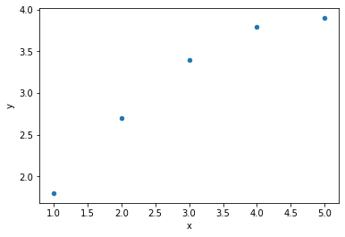

```python
X = [1, 2, 3, 4, 5]
y = [1.8, 2.7, 3.4, 3.8, 3.9]

plot_ex4(X, y)
```

#### Question 2

Check graphically that the model you obtained fits the data well using the following cell (complete the first two lines).

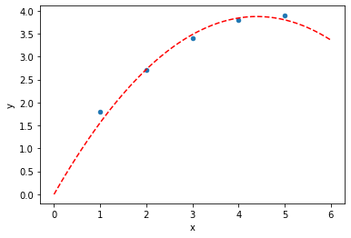

```python
X = [1, 2, 3, 4, 5]
y = [1.8, 2.7, 3.4, 3.8, 3.9]

#theta_1 =                          # <- TO UNCOMMENT AND TO COMPLETE
#theta_2 =                          # <- TO UNCOMMENT AND TO COMPLETE
### BEGIN SOLUTION
theta_1 = 1.76
theta_2 = -0.2
### END SOLUTION

plot_ex4(X, y, theta_1, theta_2)
```

## Polynomial regression with Scikit Learn

Let's play with the Scikit Learn implementation of polynomial regression. The official documentation is there: https://scikit-learn.org/stable/modules/linear_model.html#polynomial-regression-extending-linear-models-with-basis-functions

First we generate the dataset, plot it, instantiate a regressor and train it with the following code:

```
Pipeline(memory=None,
         steps=[('polynomial_features',
                 PolynomialFeatures(degree=3, include_bias=True,
                                    interaction_only=False, order='C')),
                ('linear_regression',
                 LinearRegression(copy_X=True, fit_intercept=False, n_jobs=None,
                                  normalize=False))],
         verbose=False)
```

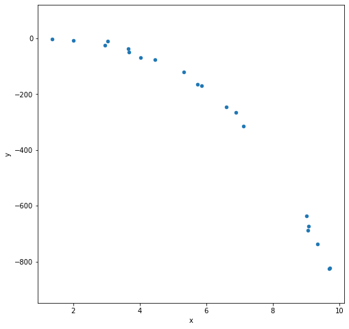

```python
df = gen_1d_polynomial_regression_samples(n_samples=20)

plot_1d_regression_samples(df)

polynomial_features = sklearn.preprocessing.PolynomialFeatures(degree=3)  # In Q. 4, try with degree = 1, 4 and 15
linear_regression = sklearn.linear_model.LinearRegression(fit_intercept=False)

model = sklearn.pipeline.Pipeline([("polynomial_features", polynomial_features),
                                   ("linear_regression", linear_regression)])

model.fit(df[['x']], df[['y']])
```

In `sklearn.preprocessing.PolynomialFeatures()`, `degree` is the degree of the polynomal function.

The following cell plots the learned model (the red dashed line) and the dataset $\mathcal{D}$ (blue points).

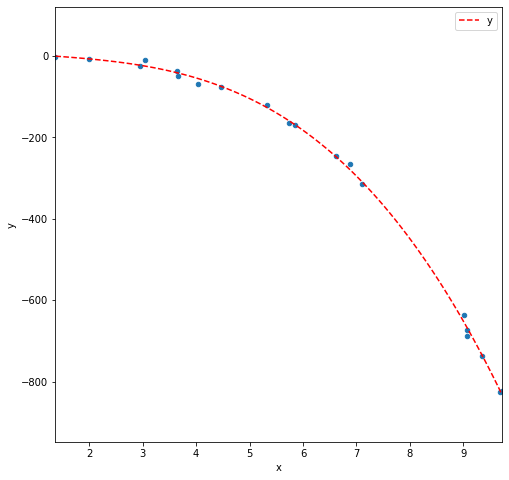

```python
plot_1d_regression_samples(df, model=model)
```

### Exercise 6

#### Question 1

What are the optimal parameters $\theta_0, \theta_1, \theta_2, \theta_3$ obtained ? (use the `linear_regression.coef_[0][0]` attribute for the intercept and `linear_regression.coef_[0][1:]` for the others coefficients)

```python
### BEGIN SOLUTION
print("theta_3:            ", linear_regression.coef_[0][3])
print("theta_2:            ", linear_regression.coef_[0][2])
print("theta_1:            ", linear_regression.coef_[0][1])
print("theta_0 (intercept):", linear_regression.coef_[0][0])
### END SOLUTION
```

```
theta_3:             -1.1671067155701973
theta_2:             3.768046027670521
theta_1:             -13.305500805211036
theta_0 (intercept): 13.619787591185476
```

#### Question 2

Write the mathematical definition of your model.

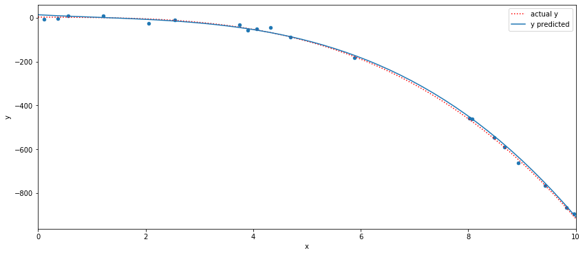

```python
### BEGIN SOLUTION
df = gen_1d_polynomial_regression_samples(n_samples=20)

ax = df.plot.scatter(x='x', y='y', figsize=(14, 6))

x = np.linspace(0., 10., 50)

y_pred = np.full(shape=x.shape, fill_value=linear_regression.coef_[0][0])
y_pred += linear_regression.coef_[0][1] * x
y_pred += linear_regression.coef_[0][2] * x**2
y_pred += linear_regression.coef_[0][3] * x**3

y = np.full(shape=x.shape, fill_value=3.)
y += -2. * x
y += x**2
y += -x**3

df_model = pd.DataFrame(np.array([x, y, y_pred]).T, columns=['x', 'y', 'y_pred'])

df_model.plot(x='x', y='y', style=':r', label='actual y', ax=ax)
df_model.plot(x='x', y='y_pred', label='y predicted', ax=ax);
### END SOLUTION
```

#### Question 3

Use the `model.predict()` function to guess the class of the following points:

$$x_{p1} = 1, \quad x_{p2} = 2, \quad x_{p3} = 6$$

```python
### BEGIN SOLUTION
model.predict(np.array([[1], [2], [6]]))
### END SOLUTION
```

```
array([[   2.9152261 ],
       [  -7.25588363],
       [-182.65861081]])
```

#### Question 4

In `sklearn.preprocessing.PolynomialFeatures()`, change the value of `degree` and describe what happen on the plot (use e.g. 1 and 15). What is the name of the observed phenomenons?

With 1 degree, it underfits:

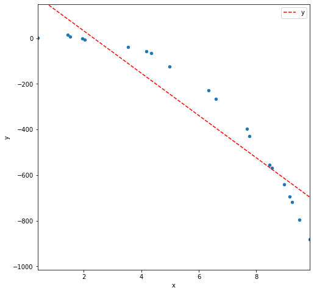

```python
### BEGIN SOLUTION
df = gen_1d_polynomial_regression_samples(n_samples=20)

polynomial_features = sklearn.preprocessing.PolynomialFeatures(degree=1)  # Try with degree = 1, 4 and 15
linear_regression = sklearn.linear_model.LinearRegression(fit_intercept=False)

model = sklearn.pipeline.Pipeline([("polynomial_features", polynomial_features),
                                   ("linear_regression", linear_regression)])

model.fit(df[['x']], df[['y']])

plot_1d_regression_samples(df, model=model)
### END SOLUTION
```

With 15 degrees, it overfits:

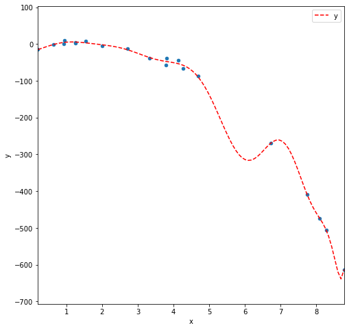

```python
### BEGIN SOLUTION
df = gen_1d_polynomial_regression_samples(n_samples=20)

polynomial_features = sklearn.preprocessing.PolynomialFeatures(degree=15)  # Try with degree = 1, 4 and 15
linear_regression = sklearn.linear_model.LinearRegression(fit_intercept=False)

model = sklearn.pipeline.Pipeline([("polynomial_features", polynomial_features),
                                   ("linear_regression", linear_regression)])

model.fit(df[['x']], df[['y']])

plot_1d_regression_samples(df, model=model) # Overfits
### END SOLUTION
```

## CO2 Emission Forecast (bonus)

In this exercise, you will forecast 5 years of future CO2 emission from power generation using natural gas.

This exercise use a dataset taken from https://www.kaggle.com/berhag/co2-emission-forecast-with-python-seasonal-arima.

This public dataset contain monthly carbon dioxide emissions from electricity generation. The dataset includes CO2 emissions starting January 1973 to July 2016.

```python
URL = "https://raw.githubusercontent.com/adimajo/polytechnique-cse204-2019-releases/master/data/natural_gas_co2_emissions_for_electric_power_sector.csv"

df = pd.read_csv(URL,
                 parse_dates=[0]) #, index_col=0) #, squeeze=True)
df.head()
```

|  | date | co2_emissions |
| --- | --- | --- |
| 0 | 1973-01-31 | 12.175 |
| 1 | 1973-02-28 | 11.708 |
| 2 | 1973-03-31 | 13.994 |
| 3 | 1973-04-30 | 14.627 |
| 4 | 1973-05-31 | 17.344 |

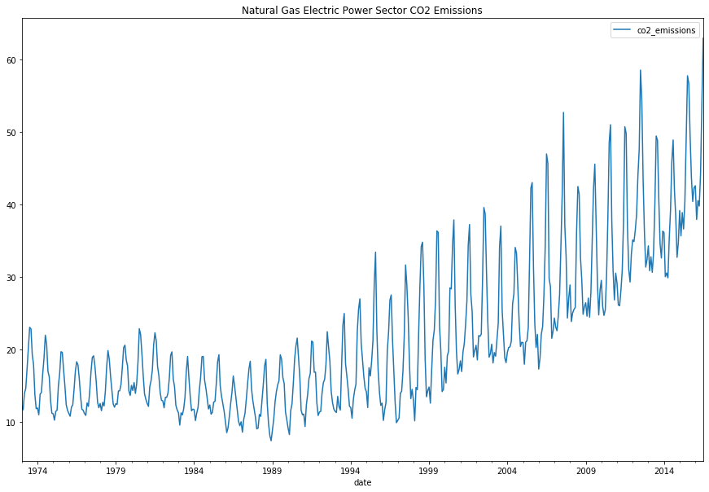

```python
df.plot(x='date', y='co2_emissions', figsize=(15,10), title='Natural Gas Electric Power Sector CO2 Emissions');
```

### Exercise 7 (bonus)

Implement a model to make predictions on this dataset. Use polynomial basis functions plus two sinusoids to handle the seasonality of this time series: $\sin(\frac{2 \pi}{12} x)$ and $\cos\left(\frac{2 \pi}{12} x \right)$. This signal contains a periodic component of 12 time steps (where one time step equals to one month).

We use both $\sin$ and $\cos$ to avoid unaligned phases with the time series. Alternatively, we could use only $\sin\left(\frac{2 \pi}{12} (x + \phi)\right)$ or $\cos\left(\frac{2 \pi}{12} (x + \phi)\right)$ as long as $\phi$ is properly set: $\phi = \pi / 2$ in the first case and $\phi = 0$ in the second one.

What are the limitations of this model?

The sine basis is not implemented in `sklearn.preprocessing.PolynomialFeatures` but Scikit Learn can be easily extended to handle any basis. See for instance: http://madrury.github.io/jekyll/update/statistics/2017/08/04/basis-expansions.html.

Here we will use a simpler method: we simply compute the $Z$ matrix as follow and apply a linear regression on it.

$$Z = \begin{pmatrix} 1 & x^{(1)} & x^{(1)2} & x^{(1)3} & \sin\left(\frac{2 \pi}{12} x^{(1)} \right) & \cos\left(\frac{2 \pi}{12} x^{(1)} \right) \\ 1 & x^{(2)} & x^{(2)2} & x^{(2)3} & \sin\left(\frac{2 \pi}{12} x^{(2)} \right) & \cos\left(\frac{2 \pi}{12} x^{(2)} \right) \\ \vdots & \vdots & \vdots & \vdots & \vdots & \vdots \\ 1 & x^{(n)} & x^{(n)2} & x^{(n)3} & \sin\left(\frac{2 \pi}{12} x^{(n)} \right) & \cos\left(\frac{2 \pi}{12} x^{(n)} \right) \end{pmatrix}$$

Reminder:

- $x^{(n)}$ is the value of $x$ for the $n^{\text{th}}$ observation in $\mathcal{D}$
- $x^{(n)2}$ is the squared value of $x$ for the $n^{\text{th}}$ observation in $\mathcal{D}$
- ...

First we make the $Z$ matrix of features:

```python
### BEGIN SOLUTION
X = df.index            # Here X is the time step index

y = df.co2_emissions

z_intercept = np.ones(shape=X.shape)
z_1 = X.copy()
z_2 = X**2
z_3 = X**3
z_sin = np.sin(2. * np.pi * X / 12.)
z_cos = np.cos(2. * np.pi * X / 12.)

Z = np.array([z_intercept, z_1, z_2, z_3, z_sin, z_cos]).T

df_Z = pd.DataFrame(Z, columns=['intercept', 'z', 'z2', 'z3', 'sin', 'cos'])
df_Z.tail()
### END SOLUTION
```

|  | intercept | z | z2 | z3 | sin | cos |
| --- | --- | --- | --- | --- | --- | --- |
| 518 | 1.0 | 518.0 | 268324.0 | 138991832.0 | 8.660254e-01 | 5.000000e-01 |
| 519 | 1.0 | 519.0 | 269361.0 | 139798359.0 | 1.000000e+00 | 2.302769e-14 |
| 520 | 1.0 | 520.0 | 270400.0 | 140608000.0 | 8.660254e-01 | -5.000000e-01 |
| 521 | 1.0 | 521.0 | 271441.0 | 141420761.0 | 5.000000e-01 | -8.660254e-01 |
| 522 | 1.0 | 522.0 | 272484.0 | 142236648.0 | 2.841800e-14 | -1.000000e+00 |

With the following plot, we check that the seasonality of the time series is correctly aligned with our sine and cosine bases:

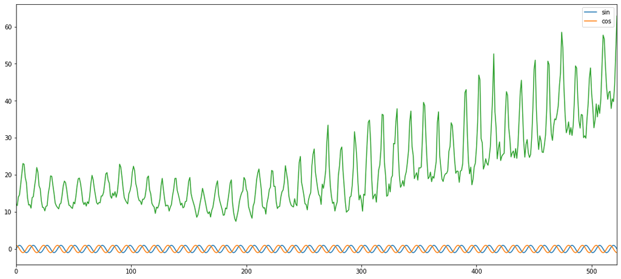

```python
### BEGIN SOLUTION
ax = df_Z.loc[:,['sin', 'cos']].plot(figsize=(18,8))
ax.plot(y);
### END SOLUTION
```

Then we make and fit the model:

```python
### BEGIN SOLUTION
model = sklearn.linear_model.LinearRegression()

model.fit(df_Z[['intercept', 'z', 'z2', 'z3', 'sin', 'cos']], y)
### END SOLUTION
```

```
LinearRegression(copy_X=True, fit_intercept=True, n_jobs=None, normalize=False)
```

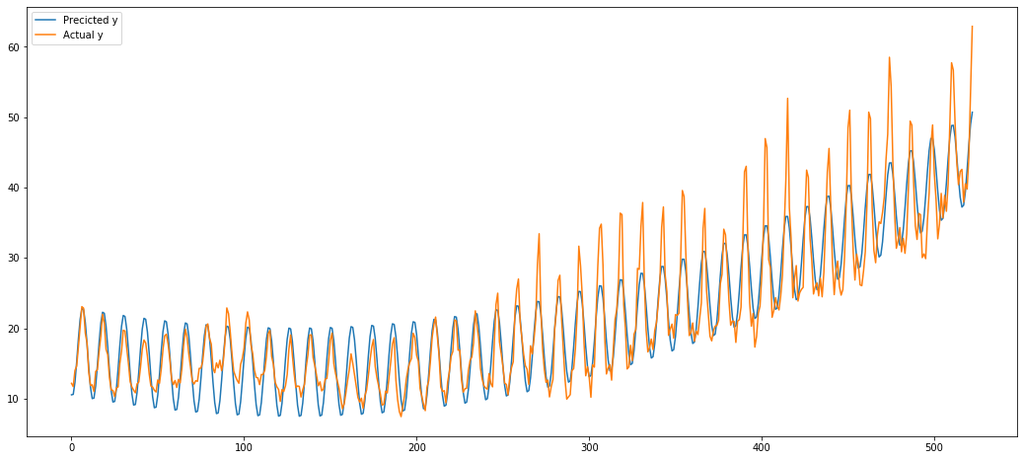

```
Coefs: [ 0.00000000e+00 -4.66407420e-02  1.74954390e-04  3.02058594e-08
 -1.45130363e+00 -6.25730714e+00]
```

```python
### BEGIN SOLUTION
fig, ax = plt.subplots(figsize=(18, 8))

# Compute the model's prediction

y_pred = model.predict(df_Z)
ax.plot(y_pred, label="Precicted y");

# Plot also the training points

ax.plot(y, label="Actual y")
ax.legend()
plt.show()

print("Coefs:", model.coef_)
### END SOLUTION
```

Then we use the model to (roughly) forecast the CO2 emission for the 5 next years:

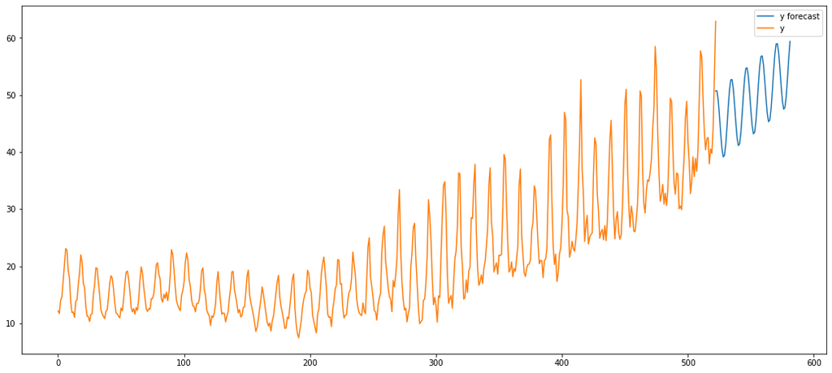

```python
### BEGIN SOLUTION
X_forecast = np.arange(12 * 5) + df.index[-1]            # Here X is the time step index

z_intercept = np.ones(shape=X_forecast.shape)
z_1 = X_forecast.copy()
z_2 = X_forecast**2
z_3 = X_forecast**3
z_sin = np.sin(2. * np.pi * X_forecast / 12.)
z_cos = np.cos(2. * np.pi * X_forecast / 12.)

Z_forecast = np.array([z_intercept, z_1, z_2, z_3, z_sin, z_cos]).T

df_Z_forecast = pd.DataFrame(Z_forecast, columns=['intercept', 'z', 'z2', 'z3', 'sin', 'cos'])

# Compute the model's prediction

y_forecast = model.predict(df_Z_forecast)

# Plot also the training points

fig, ax = plt.subplots(figsize=(18, 8))

ax.plot(X_forecast, y_forecast, label="y forecast")
ax.plot(X, y, label="y")

ax.legend();
### END SOLUTION
```

The following cell gather all steps to quickly test other bases:

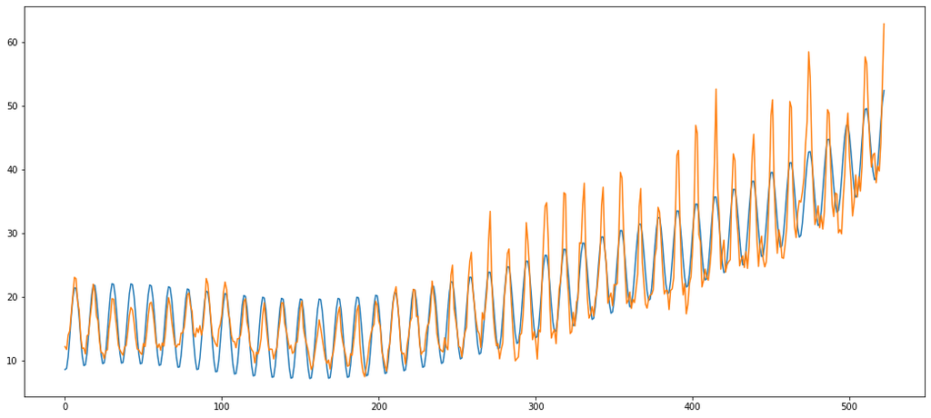

```
Coefs: [ 1.48108139e+01  6.67060125e-02 -1.32771064e-03  7.62928787e-06
 -1.62372488e-08  1.23517863e-11 -1.44953511e+00 -6.24710545e+00]
```

```python
#### BEGIN SOLUTION
X = df.index           # Here X is the time step index

y = df.co2_emissions

z_intercept = np.ones(shape=X.shape)
z_1 = X.copy()
z_2 = X**2
z_3 = X**3
z_4 = X**4
z_5 = X**5
z_sin = np.sin(2. * np.pi / 12. * X)                  # Bad results when no other sinusoid complete this one (when index starts at 0)
#z_sin = np.sin(2. * np.pi / 12. * X + np.pi / 2.)    # Ok, equiv np.cos(2. * np.pi * X / 12.)
z_cos = np.cos(2. * np.pi / 12. * X)                  # Ok
#z_sin2 = np.sin(2. * np.pi / (12. * 9) * X)          # Ok but almost useless
#z_cos2 = np.cos(2. * np.pi / (12. * 9) * X)          # Ok but almost useless

Z = np.array([z_intercept,
              z_1,
              z_2,
              z_3,
              z_4,
              z_5,
              z_sin,
              z_cos,
              #z_sin2,
              #z_cos2
             ]).T

df_Z = pd.DataFrame(Z, columns=['intercept',
                                'z',
                                'z2',
                                'z3',
                                'z4',
                                'z5',
                                'sin',
                                'cos',
                                #'sin2',
                                #'cos2'
                               ])

# Make and fit the model

model = sklearn.linear_model.LinearRegression(fit_intercept=False)
model.fit(df_Z, y)

# Compute the model's prediction

y_pred = model.predict(df_Z)

# Plot also the training points

fig, ax = plt.subplots(figsize=(18, 8))
ax.plot(y_pred)
ax.plot(y)
plt.show()

print("Coefs:", model.coef_)
### END SOLUTION
```